# Lab Sheet 3

STAT260, University of Otago

Sem. 2, 2021

# Task 1

We will again be using the data in `aki.csv`. Call this data into R in the space below.

We will be focusing on three variables in the lab today:

- `uCysC`: the urine cystatin C concentration at admission. The interest in this study was to determine the potential for this measure to be used as a biomarker for acute kidney disease.
- `age` (years)
- `weight` (kg)

*Answer:*

```r
akidata <- read.csv("../lab02/aki.csv",stringsAsFactors=TRUE)
head(akidata)
```

|  | AKI | Death_30 | uCysC | sex | age | ethnic | weight | COPD | diab | hyper |
| --- | --- | --- | --- | --- | --- | --- | --- | --- | --- | --- |
| 1 | 1 | 1 | 11.20 | 1 | 75.18344 | New Zealand/European | 70 | 0 | 0 | 1 |
| 2 | 1 | 0 | 0.05 | 0 | 20.50433 | New Zealand/European | 85 | 0 | 0 | 0 |
| 3 | 1 | 0 | 0.09 | 0 | 72.64538 | New Zealand/European | 75 | 0 | 0 | 1 |
| 4 | 1 | 0 | 0.05 | 1 | 50.03833 | New Zealand/European | 88 | 0 | 0 | 1 |
| 5 | 1 | 0 | 0.05 | 0 | 18.04567 | Other European | 77 | 0 | 0 | 0 |
| 6 | 0 | 0 | 0.05 | 0 | 43.40981 | Other | 85 | 0 | 0 | 0 |

# Task 2

Produce a scatterplot of the `uCysC` value (y-axis) against age (x-axis). Ensure you label both the x and y axes (you should do this for all plots you make).

*Answer:*

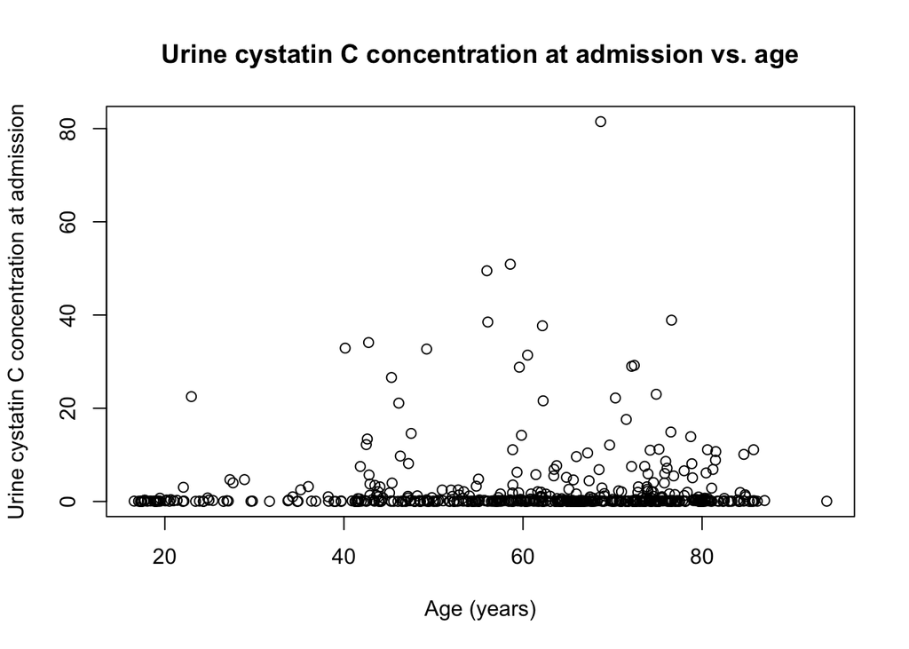

```r
plot(y=akidata$uCysC, x=akidata$age, main = "Urine cystatin C concentration at admission vs. age", ylab = "Urine cystatin C concentration at admission", xlab= "Age (years)")
```

# Task 3

The plot in Task 2 is not very informative because of the long right tail in the `uCysC` distribution. Provide histograms of both `uCysC` and the log transform of `uCysC`. Comment on the shape of these distributions.

*Answer:*

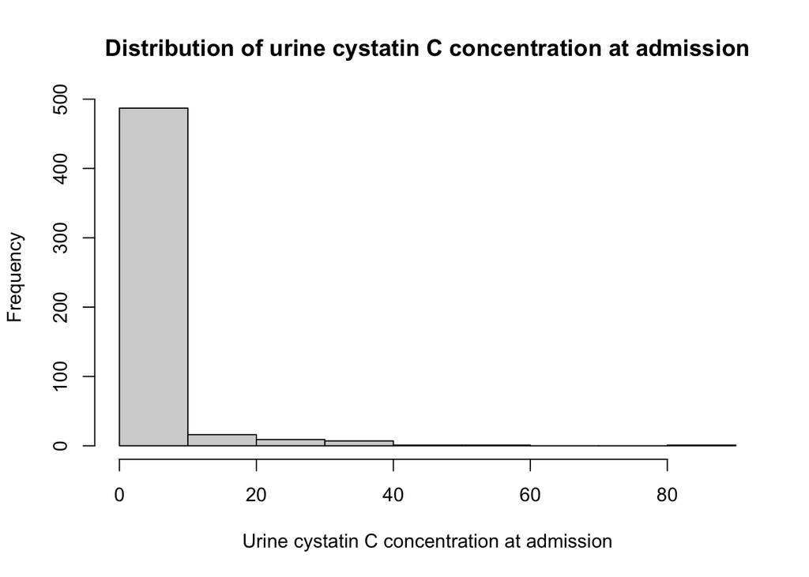

```r
hist(akidata$uCysC, main = "Distribution of urine cystatin C concentration at admission", xlab = "Urine cystatin C concentration at admission")
```

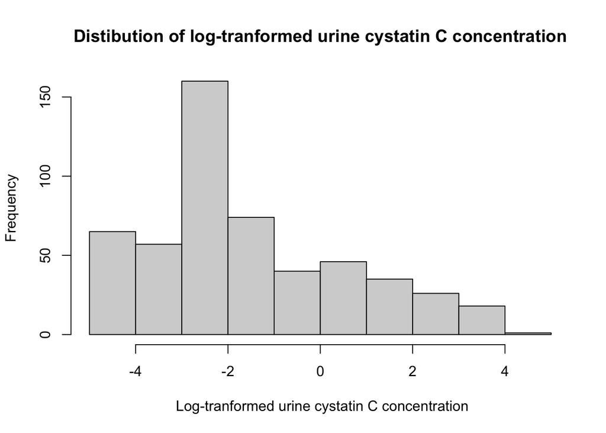

```r
hist(log(akidata$uCysC), main = "Distibution of log-tranformed urine cystatin C concentration", xlab = " Log-tranformed urine cystatin C concentration")
```

# Task 4

Provide a scatterplot of the log of `uCysC` against `age`. Change the colour of the points using the option `col = "goldenrod"`. Change the point character (you can choose which character to use).

*Answer:*

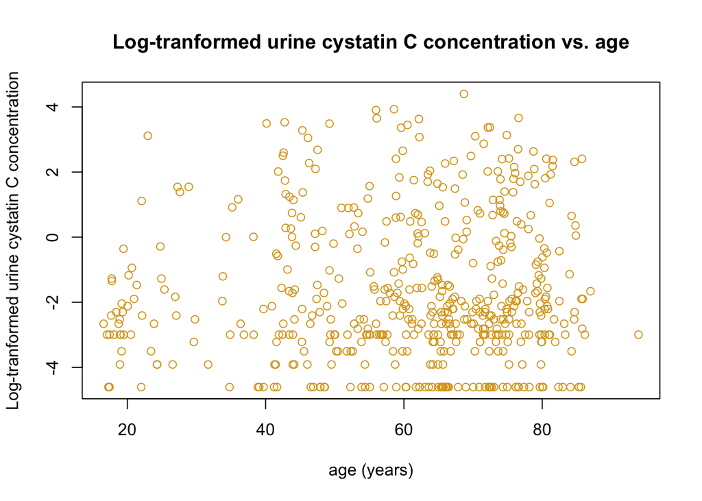

```r
plot(akidata$age, log(akidata$uCysC), col = "goldenrod", main = "Log-tranformed urine cystatin C concentration vs. age", xlab = "age (years)", ylab = "Log-tranformed urine cystatin C concentration")
```

# Task 5

Suppose that we later found another sheet of paper another 3 datapoints on it. These observations are given in `uCysC_extra` and `age_extra`:

```r
uCysC_extra <- c(0.06,0.30,0.13)
age_extra <- c(52,37,81)
```

Copy and paste your R code from Task 4 (to produce the scatterplot). Then use `points` to add the extra points. Make sure these are a different colour and point character so that you can see them. HINT 1: The `points` function is used in the same way as the plot function with `points(x,y)`. HINT 2: You change the colour and point character of the points in the same way as you do with the plot function. HINT 3: Remember we need all response values to be on the log scale.

*Answer:*

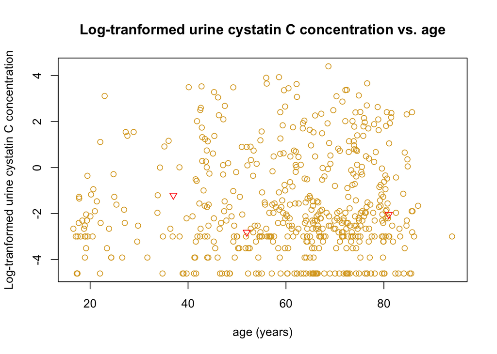

```r
plot(akidata$age, log(akidata$uCysC), col = "goldenrod", main = "Log-tranformed urine cystatin C concentration vs. age", xlab = "age (years)", ylab = "Log-tranformed urine cystatin C concentration")
points(y= log(uCysC_extra), x = age_extra, col ="red", pch = 6)
```

# Task 6

Finally, plot two additional scatterplots. The first should be the log of `uCysC` against `weight`. The second should be `weight` against `age`. Do either of these plots suggest an interesting relationship between the variables?

*Answer:*

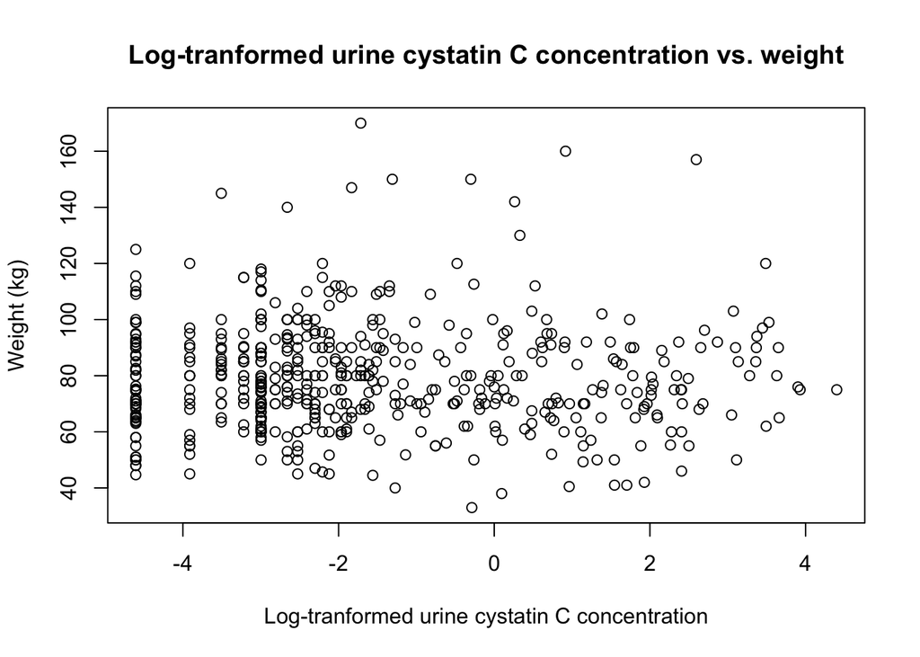

```r
plot(log(akidata$uCysC), akidata$weight, main = "Log-tranformed urine cystatin C concentration vs. weight", xlab = "Log-tranformed urine cystatin C concentration", ylab = "Weight (kg)")
```

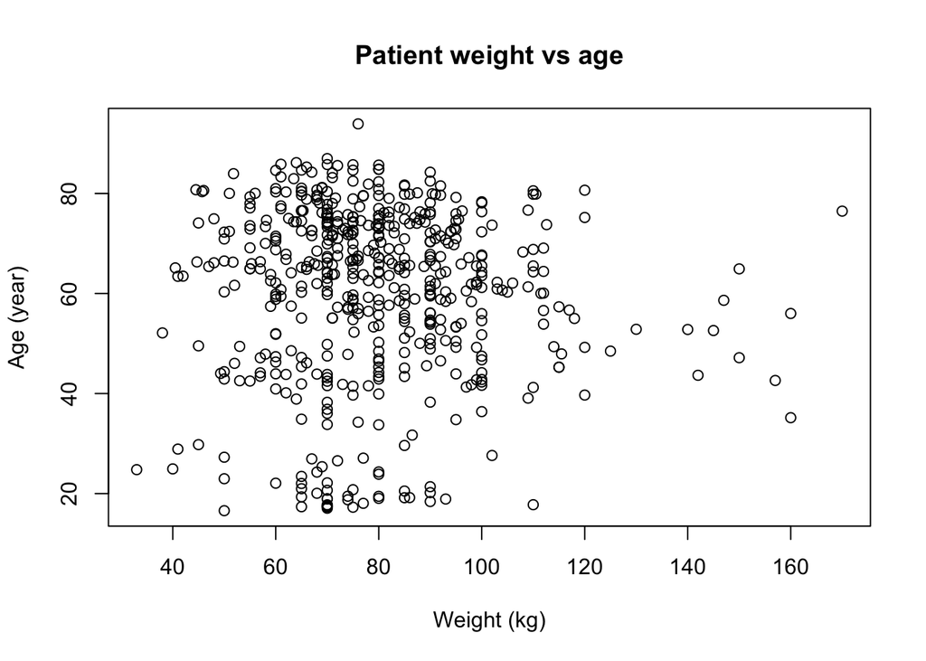

```r
plot(akidata$weight, akidata$age, main = "Patient weight vs age", xlab = "Weight (kg)", ylab = "Age (year)")
```

******